# Costos del SPB y Justicia por delitos por infracción a la ley 23737 (años 2018 y 2019)

```r
library(dplyr)
library(ggplot2)
library(readr)
library(tidyr)
options(scipen = 999)
```

# Justicia

## Aclaraciones metodológicas:

Para la construcción de esta información, trabajamos con los sueldos de lxs magistradxs de Poder Judicial y Ministerio Público vinculados con la investigación y juzgamiento de los delitos de la ley 23.737 (más abajo, se especifica la cantidad por instancia y categoría en la escala salarial), agregándole a cada magistradx 1 secretarix y 1 auxiliar letradx. Por falta de información, no fue posible considerar a la totalidad de lxs funcionarixs y empleadxs. Por esta misma razón, tampoco se incluyó a Suprema Corte y Juzgados de Ejecución ni en general a cualquier otro gasto corriente que no tenga que ver con sueldos como es el papel, internet, luz, pericias, gastos de transporte, mantenimiento, etcétera.

Por lo tanto, la presente estimación es el piso mínimo del gasto. Para todas las cuentas utilizamos los archivos PDF “Escala Salarial 2018” y “Escala salarial 2019”.

#### Categorias

```r
categoria.22.18 <- 47917*2+49778*4+53500*2+55360*1+60478*2+61408
categoria.22.19 <- 65000*2+66014*2+68470*2+76822*2+79831*4

categoria.21.18 <- 40823*2+42408*4+45579*2+47164*1+51524*2+52316
categoria.21.19 <- 55000*2+56240*2+58333*2+65448*2+68012*4

categoria.20.18 <- 35123*2+36487*4+39215*2+40579*1+44330*2+45012
categoria.20.19 <- 46000*2+48388*2+50188*2+56310*2+58515*4

categoria.1925.18 <- 31957*2+33198*4+35680*2+36921*1+40334*2+40955
categoria.1925.19 <- 43000*2+44026*2+45664*2+51234*2+53241*4

categoria.19.18 <- 29508*2+30654*4+32946*2+34092*1+37243*2+37816
categoria.19.19 <- 39500*2+40652*2+42165*2+47308*2+49161*4

categoria.1875.18 <- 28671*2+29785*4+32012*2+33125*1+36187*2+36744
categoria.1875.19 <- 38500*2+39500*2+40969*2+45967*2+47767*4
```

## Suprema Corte

No contamos con información que nos permita calcular.

## Tribunal de Casación

- 8 jueces/zas categoría 22 completa
- 2 jueces/zas categoría 22 30% (subrogantes)

*El número de magistradxs lo obtuvimos de relevar la página de la SC el 14/12/2020 y revisar la integración del Tribunal durante el 2018 y 2019. El proporcional de su salario lo calculamos en función de estadísticas realizadas por la Sala I del mencionado Tribunal, es el Word “Porcentajes casación ley 23.737”.

```r
casacion.porcen.18 <- 0.1145
casacion.porcen.19 <- 0.1068

casacion.cantidad.juez <- 8 + (0.3*2)

casacion.costo.18 <- casacion.porcen.18*categoria.22.18*casacion.cantidad.juez
casacion.costo.19 <- casacion.porcen.19*categoria.22.19*casacion.cantidad.juez

print(paste0('Costo casación 2018: $', casacion.costo.18))
```

```
[1] "Costo casación 2018: $629883.049"
```

```r
print(paste0('Costo casación 2019: $', casacion.costo.19))
```

```
[1] "Costo casación 2019: $800855.77728"
```

#### Con Secretarios/as y Auxiliares letrados

- 12 secretarios/as Poder Judicial Categoría 20 completa. Mismo proporcional que magistradxs.
- 12 auxiliares letradxs Poder Judicial Categoría 19.25 completa. Mismo proporcional que magistradxs.

```r
casacion.cantidad.secre <- 12
casacion.cantidad.auxi <- 12

ad.casacion.costo.18 <- (casacion.porcen.18*categoria.20.18*casacion.cantidad.secre) + (casacion.porcen.18*categoria.1925.18*casacion.cantidad.auxi)
ad.casacion.costo.19 <- (casacion.porcen.19*categoria.20.19*casacion.cantidad.secre) + (casacion.porcen.19*categoria.1925.19*casacion.cantidad.auxi)

print(paste0('Costo casación 2018 (con secre y auxi): $', casacion.costo.18 + ad.casacion.costo.18))
```

```
[1] "Costo casación 2018 (con secre y auxi): $1860279.439"
```

```r
print(paste0('Costo casación 2019 (con secre y auxi): $', casacion.costo.19 + ad.casacion.costo.19))
```

```
[1] "Costo casación 2019 (con secre y auxi): $2360106.72768"
```

## Fiscal y defensor ante la Casación

- 1 fiscal categoría 22 completa
- 1 defensor categoría 22 completa

*El número de magistradxs lo obtuvimos de relevar la página de la SC el 14/12/2020 y revisar la integración del Tribunal durante el 2018 y 2019. El proporcional de su salario lo calculamos en función de estadísticas realizadas por la Sala I del mencionado Tribunal, es el Word “Porcentajes casación ley 23.737”.

```r
fiscal.casacion.porcen.18 <- 0.1145
fiscal.casacion.porcen.19 <- 0.1068

categoria.22.18 <- 47917*2+49778*4+53500*2+55360*1+60478*2+61408
categoria.22.19 <- 65000*2+66014*2+68470*2+76822*2+79831*4

fiscal.casacion.cantidad <- 2

fiscal.casacion.costo.18 <- fiscal.casacion.porcen.18*categoria.22.18*fiscal.casacion.cantidad
fiscal.casacion.costo.19 <- fiscal.casacion.porcen.19*categoria.22.19*fiscal.casacion.cantidad

print(paste0('Costo fiscal y defensor casación 2018: $', fiscal.casacion.costo.18))
```

```
[1] "Costo fiscal y defensor casación 2018: $146484.43"
```

```r
print(paste0('Costo fiscal y defensor casación 2019: $', fiscal.casacion.costo.19))
```

```
[1] "Costo fiscal y defensor casación 2019: $186245.5296"
```

#### Con Secretarios/as y Auxiliares letrados

- 2 secretarios/as Ministerio Público categoría 20 completa. Mismo proporcional que magistradxs.
- 2 auxiliares letradxs Ministerio Público Categoría 19.25 completa. Mismo proporcional que magistradxs.

```r
fiscal.casacion.cantidad.secre <- 2
fiscal.casacion.cantidad.auxi <- 2

ad.fiscal.casacion.costo.18 <- (fiscal.casacion.porcen.18*categoria.20.18*fiscal.casacion.cantidad.secre) + (fiscal.casacion.porcen.18*categoria.1925.18*fiscal.casacion.cantidad.auxi)
ad.fiscal.casacion.costo.19 <- (fiscal.casacion.porcen.19*categoria.20.19*fiscal.casacion.cantidad.secre) + (fiscal.casacion.porcen.19*categoria.1925.19*fiscal.casacion.cantidad.auxi)

print(paste0('Costo fiscal y defensor casación 2018 (con secre y auxi): $', fiscal.casacion.costo.18 + ad.fiscal.casacion.costo.18))
```

```
[1] "Costo fiscal y defensor casación 2018 (con secre y auxi): $351550.495"
```

```r
print(paste0('Costo fiscal y defensor casación 2019 (con secre y auxi): $', fiscal.casacion.costo.19 + ad.fiscal.casacion.costo.19))
```

```
[1] "Costo fiscal y defensor casación 2019 (con secre y auxi): $446120.688"
```

## Cámaras departamentales

- 92 jueces/zas categoría 21 completa
- 2 jueces/zas categoría 21 30% (subrogantes)

*El número de magistradxs lo obtuvimos de relevar la página de la SC el 14/12/2020. El proporcional de su salario lo calculamos en función de las estadísticas del MP sobre cantidad de IPP por ley 23.737. A su vez, a los fines de estas estimaciones, consideramos que la disminución de caudal de trabajo entre Juzgado de Garantías y Tribunales se da de modo proporcional para cada delito. El archivo que tiene los porcentajes de este fuero es el Excel “Fuero Criminal y Correccional 2018 2019”.

```r
camaras.porcen.18 <- 0.0687
camaras.porcen.19 <- 0.089

categoria.21.18 <- 40823*2+42408*4+45579*2+47164*1+51524*2+52316
categoria.21.19 <- 55000*2+56240*2+58333*2+65448*2+68012*4

camaras.cantidad <- 92 + (0.3 * 2) # jueces sueldo completo + (cantidad sub * sueldo prop)

camaras.costo.18 <- camaras.porcen.18*categoria.21.18*camaras.cantidad
camaras.costo.19 <- camaras.porcen.19*categoria.21.19*camaras.cantidad

print(paste0('Costo camaras departamentales 2018: $', camaras.costo.18))
```

```
[1] "Costo camaras departamentales 2018: $3466853.88168"
```

```r
print(paste0('Costo camaras departamentales 2019: $', camaras.costo.19))
```

```
[1] "Costo camaras departamentales 2019: $6115860.526"
```

#### Con Secretarios/as y Auxiliares letrados

- 111 secretarios/as Poder Judicial categoría 19.25 completa. Mismo proporcional que magistradxs.
- 111 auxiliares letradxs Poder Judicial categoría 19 completa. Mismo proporcional que magistradxs.

```r
camaras.cantidad.secre <- 111
camaras.cantidad.auxi <- 111

ad.camaras.costo.18 <- (camaras.porcen.18*categoria.1925.18*camaras.cantidad.secre) + (camaras.porcen.18*categoria.19.18*camaras.cantidad.auxi)

ad.camaras.costo.19 <- (camaras.porcen.19*categoria.1925.19*camaras.cantidad.secre) + (camaras.porcen.19*categoria.19.19*camaras.cantidad.auxi)

print(paste0('Costo camaras departamentales 2018 (con secre y auxi): $', camaras.costo.18 + ad.camaras.costo.18))
```

```
[1] "Costo camaras departamentales 2018 (con secre y auxi): $9723954.25128"
```

```r
print(paste0('Costo camaras departamentales 2019 (con secre y auxi): $', camaras.costo.19 + ad.camaras.costo.19))
```

```
[1] "Costo camaras departamentales 2019 (con secre y auxi): $17147799.1"
```

## Juzgados de Garantías y Tribunales Criminales

- 261 jueces/juezas categoría 20 completa
- 14 jueces/zas categoría 20 30% (subrogantes)
- 8 jueces/zas categoría 20 completa (suplentes)

*El número de magistradxs lo obtuvimos de relevar la página de la SC el 14/12/2020. El proporcional de su salario lo calculamos en función de las estadísticas del MP sobre cantidad de IPP por ley 23.737. A su vez, a los fines de estas estimaciones, consideramos que la disminución de caudal de trabajo entre Juzgado de Garantías y Tribunales se da de modo proporcional para cada delito. El archivo que tiene los porcentajes de este fuero es el Excel “Fuero Criminal y Correccional 2018 2019”.

```r
garantias.tribunales.porcen.18 <- 0.0687
garantias.tribunales.porcen.19 <- 0.089

categoria.20.18 <- 35123*2+36487*4+39215*2+40579*1+44330*2+45012
categoria.20.19 <- 46000*2+48388*2+50188*2+56310*2+58515*4

garantias.tribunales.cantidad.jgarantias <- 88 + (0.3 * 3) + 2
# j.garantias + j.garantias subrogantes + j.garantias suplentes
garantias.tribunales.cantidad.jtribunal <- 173 + (0.3 * 11) + 6
# j.tribunal + j.tribunal subrogantes + j.tribunal suplentes

garantias.tribunales.costo.18 <- garantias.tribunales.porcen.18* categoria.20.18* (garantias.tribunales.cantidad.jgarantias+garantias.tribunales.cantidad.jtribunal)

garantias.tribunales.costo.19 <- garantias.tribunales.porcen.19* categoria.20.19* (garantias.tribunales.cantidad.jgarantias+garantias.tribunales.cantidad.jtribunal)

print(paste0('Costo Juzgados de Garantías y Tribunales Criminales 2018: $', garantias.tribunales.costo.18))
```

```
[1] "Costo Juzgados de Garantías y Tribunales Criminales 2018: $8800239.855"
```

```r
print(paste0('Costo Juzgados de Garantías y Tribunales Criminales 2019: $', garantias.tribunales.costo.19))
```

```
[1] "Costo Juzgados de Garantías y Tribunales Criminales 2019: $15460127.9136"
```

#### Con Secretarios/as y Auxiliares letrados

- 312 secretarios/as Poder Judicial categoría 19 completa. Misto proporcional que magistradxs.
- 312 auxiliares letradxs Poder Judicial categoría 18.75. Mismo proporcional que magistradxs.

```r
garantias.tribunales.cantidad.secre <- 312
garantias.tribunales.cantidad.auxi <- 312

ad.garantias.tribunales.costo.18 <- (garantias.tribunales.porcen.18*categoria.19.18*garantias.tribunales.cantidad.secre) + (garantias.tribunales.porcen.18*categoria.1875.18*garantias.tribunales.cantidad.auxi)

ad.garantias.tribunales.costo.19 <- (garantias.tribunales.porcen.19*categoria.19.19*garantias.tribunales.cantidad.secre) + (garantias.tribunales.porcen.19*categoria.1875.19*garantias.tribunales.cantidad.auxi)

print(paste0('Costo Juzgados de Garantías y Tribunales Criminales 2018 (con secre y auxi): $', garantias.tribunales.costo.18 + ad.garantias.tribunales.costo.18))
```

```
[1] "Costo Juzgados de Garantías y Tribunales Criminales 2018 (con secre y auxi): $25447630.9998"
```

```r
print(paste0('Costo Juzgados de Garantías y Tribunales Criminales 2019 (con secre y auxi): $', garantias.tribunales.costo.19 + ad.garantias.tribunales.costo.19))
```

```
[1] "Costo Juzgados de Garantías y Tribunales Criminales 2019 (con secre y auxi): $44806294.4256"
```

## Agentes fiscales Ley 23.737

- 61 agentes fiscales categoría 20 completa

*La cantidad de agentes fiscales dedicados a los delitos de la ley 23.737, en los años 2018 y 2019, lo obtuvimos del informe 2018 sobre estupefacientes del MP. En este caso, dado que estos magistradxs están exclusivamente avocados a esta clase de causas no calculamos el proporcional sino el 100% de su salario.

```r
fiscales.porcen.18 <- 1
fiscales.porcen.19 <- 1

categoria.20.18 <- 35123*2+36487*4+39215*2+40579*1+44330*2+45012
categoria.20.19 <- 46000*2+48388*2+50188*2+56310*2+58515*4

fiscales.cantidad <- 61

fiscales.costo.18 <- fiscales.porcen.18*categoria.20.18*fiscales.cantidad
fiscales.costo.19 <- fiscales.porcen.19*categoria.20.19*fiscales.cantidad

print(paste0('Costo agentes fiscales 2018: $', fiscales.costo.18))
```

```
[1] "Costo agentes fiscales 2018: $28601375"
```

```r
print(paste0('Costo agentes fiscales 2019: $', fiscales.costo.19))
```

```
[1] "Costo agentes fiscales 2019: $38785752"
```

#### Con Secretarios/as y Auxiliares letrados

- 61 secretarios/as categoría 19.25 completa. Mismo proporcional que magistradxs.
- 61 auxiliares letradxs categoría 18.75 completa. Mismo proporcional que magistradxs.

```r
fiscales.cantidad.secre <- 61
fiscales.cantidad.auxi <- 61

ad.fiscales.costo.18 <- (fiscales.porcen.18*categoria.1925.18*fiscales.cantidad.secre) + (fiscales.porcen.18*categoria.1875.18*fiscales.cantidad.auxi)

ad.fiscales.costo.19 <- (fiscales.porcen.19*categoria.1925.19*fiscales.cantidad.secre) + (fiscales.porcen.19*categoria.1875.19*fiscales.cantidad.auxi)

print(paste0('Costo agentes fiscales 2018 (con secre y auxi): $', fiscales.costo.18 + ad.fiscales.costo.18))
```

```
[1] "Costo agentes fiscales 2018 (con secre y auxi): $77972274"
```

```r
print(paste0('Costo agentes fiscales 2019 (con secre y auxi): $', fiscales.costo.19 + ad.fiscales.costo.19))
```

```
[1] "Costo agentes fiscales 2019 (con secre y auxi): $105992624"
```

## Defensores/as ante juzgados de garantías y tribunales criminales

- 57 defensores/as categoría 20 completa

*La cantidad de defensores/as la determinamos en función de la cantidad de defensorías por departamento judicial y, en función de la organización del sistema acusatorio, teniendo en cuenta la cantidad de fiscales especializados en la materia. Para calcular el proporcional del sueldo de cada magistradx, utilizamos las estadísticas sobre IPP del MP. El archivo que tiene los porcentajes es el Excel “Fuero Criminal y Correccional 2018 2019”.

```r
defensores.porcen.18 <- 0.0687
defensores.porcen.19 <- 0.089

categoria.20.18 <- 35123*2+36487*4+39215*2+40579*1+44330*2+45012
categoria.20.19 <- 46000*2+48388*2+50188*2+56310*2+58515*4

defensores.cantidad <- 57

defensores.costo.18 <- defensores.porcen.18*categoria.20.18*defensores.cantidad
defensores.costo.19 <- defensores.porcen.19*categoria.20.19*defensores.cantidad

print(paste0('Costo defensores 2018: $', defensores.costo.18))
```

```
[1] "Costo defensores 2018: $1836067.6125"
```

```r
print(paste0('Costo defensores 2019: $', defensores.costo.19))
```

```
[1] "Costo defensores 2019: $3225575.736"
```

#### Con Secretarios/as y Auxiliares letrados

- 57 secretarios/as categoría 19.25 completa. Mismo proporcional que magistradxs.
- 57 auxiliares letradxs categoría 18.75 completa. Mismo proporcional que magistradxs.

```r
defensores.cantidad.secre <- 57
defensores.cantidad.auxi <- 57

ad.defensores.costo.18 <- (defensores.porcen.18*categoria.1925.18*defensores.cantidad.secre) + (defensores.porcen.18*categoria.1875.18*defensores.cantidad.auxi)

ad.defensores.costo.19 <- (defensores.porcen.19*categoria.1925.19*defensores.cantidad.secre) + (defensores.porcen.19*categoria.1875.19*defensores.cantidad.auxi)

print(paste0('Costo defensores 2018 (con secre y auxi): $', defensores.costo.18 + ad.defensores.costo.18))
```

```
[1] "Costo defensores 2018 (con secre y auxi): $5005436.5206"
```

```r
print(paste0('Costo defensores 2019 (con secre y auxi): $', defensores.costo.19 + ad.defensores.costo.19))
```

```
[1] "Costo defensores 2019 (con secre y auxi): $8814763.632"
```

## Fuero de responsabilidad penal juvenil

```r
rpj.porcen.18 <- 0.0605
rpj.porcen.19 <- 0.0821

rpj.cantidad.juez <- 69 # jueces
rpj.cantidad.fiscal.defensor <- 64 + 53 + (1 * 0.3) # fiscales + defensores + subrogantes
rpj.cantidad <- rpj.cantidad.juez + rpj.cantidad.fiscal.defensor

rpj.costo.18.juez <- rpj.porcen.18*categoria.20.18*rpj.cantidad.juez
rpj.costo.18.fiscal.defensor <- rpj.porcen.18*categoria.20.18*rpj.cantidad.fiscal.defensor
rpj.costo.18 <- rpj.costo.18.juez + rpj.costo.18.fiscal.defensor

rpj.costo.19.juez <- rpj.porcen.19*categoria.20.19*rpj.cantidad.juez
rpj.costo.19.fiscal.defensor <- rpj.porcen.19*categoria.20.19*rpj.cantidad.fiscal.defensor
rpj.costo.19 <- rpj.costo.19.juez + rpj.costo.19.fiscal.defensor

print(paste0('Costo fuero responsabilidad penal juvenil 2018: $', rpj.costo.18))
```

```
[1] "Costo fuero responsabilidad penal juvenil 2018: $5284760.45625"
```

```r
print(paste0('Costo fuero responsabilidad penal juvenil 2019: $', rpj.costo.19))
```

```
[1] "Costo fuero responsabilidad penal juvenil 2019: $9725196.68136"
```

#### Con Secretarios/as y Auxiliares letrados

```r
rpj.cantidad.secre.juez <- 57
rpj.cantidad.auxi.juez <- 57
rpj.cantidad.secre.fiscal.defensor <- 119
rpj.cantidad.auxi.fiscal.defensor <- 119
rpj.cantidad <- rpj.cantidad.secre.juez + rpj.cantidad.auxi.juez + rpj.cantidad.secre.fiscal.defensor + rpj.cantidad.auxi.fiscal.defensor


ad.rpj.costo.18.juez <-
  (rpj.porcen.18*categoria.1925.18*rpj.cantidad.secre.juez) +
  (rpj.porcen.18*categoria.1875.18*rpj.cantidad.auxi.juez)
ad.rpj.costo.18.fiscal.defensor <-
  (rpj.porcen.18*categoria.1925.18*rpj.cantidad.secre.fiscal.defensor) +
  (rpj.porcen.18*categoria.1875.18*rpj.cantidad.auxi.fiscal.defensor)
ad.rpj.costo.18 <- ad.rpj.costo.18.juez + ad.rpj.costo.18.fiscal.defensor

ad.rpj.costo.19.juez <-
  (rpj.porcen.19*categoria.1925.19*rpj.cantidad.secre.juez) +
  (rpj.porcen.19*categoria.1875.19*rpj.cantidad.auxi.juez)
ad.rpj.costo.19.fiscal.defensor <-
  (rpj.porcen.19*categoria.1925.19*rpj.cantidad.secre.fiscal.defensor) +
  (rpj.porcen.19*categoria.1875.19*rpj.cantidad.auxi.fiscal.defensor)
ad.rpj.costo.19 <- ad.rpj.costo.19.juez + ad.rpj.costo.19.fiscal.defensor

print(paste0('Costo fuero responsabilidad penal juvenil 2018 (con secre y auxi): $', rpj.costo.18 + ad.rpj.costo.18))
```

```
[1] "Costo fuero responsabilidad penal juvenil 2018 (con secre y auxi): $13902815.08825"
```

```r
print(paste0('Costo fuero responsabilidad penal juvenil 2019 (con secre y auxi): $', rpj.costo.19 + ad.rpj.costo.19))
```

```
[1] "Costo fuero responsabilidad penal juvenil 2019 (con secre y auxi): $25645072.38056"
```

## Juzgados de Ejecución Penal

No contamos con información que nos permita calcular.

## Total costo (Justicia)

#### Sin Secretarios/as y Auxiliares letrados

```r
print(paste0('Costo total 2018: $',
casacion.costo.18 + fiscal.casacion.costo.18 + camaras.costo.18 + fiscales.costo.18 + defensores.costo.18 + rpj.costo.18 + garantias.tribunales.costo.18))
```

```
[1] "Costo total 2018: $48765664.28443"
```

```r
print(paste0('Costo total 2019: $',
casacion.costo.19 + fiscal.casacion.costo.19 + camaras.costo.19 + fiscales.costo.19 + defensores.costo.19 + rpj.costo.19 + garantias.tribunales.costo.19))
```

```
[1] "Costo total 2019: $74299614.16384"
```

#### Con Secretarios/as y Auxiliares letrados

```r
print(paste0('Costo total (Con Secretarios/as y Auxiliares letrados) 2018: $',
casacion.costo.18 +ad.casacion.costo.18 +
fiscal.casacion.costo.18 +ad.fiscal.casacion.costo.18 +
camaras.costo.18 +ad.camaras.costo.18 +
fiscales.costo.18 +ad.fiscales.costo.18 +
defensores.costo.18 +ad.defensores.costo.18 +
rpj.costo.18 +ad.rpj.costo.18 +
garantias.tribunales.costo.18 +ad.garantias.tribunales.costo.18))
```

```
[1] "Costo total (Con Secretarios/as y Auxiliares letrados) 2018: $134263940.79393"
```

```r
print(paste0('Costo total (Con Secretarios/as y Auxiliares letrados) 2019: $',
casacion.costo.19 +ad.casacion.costo.19 +
fiscal.casacion.costo.19 +ad.fiscal.casacion.costo.19 +
camaras.costo.19 +ad.camaras.costo.19 +
fiscales.costo.19 +ad.fiscales.costo.19 +
defensores.costo.19 +ad.defensores.costo.19 +
rpj.costo.19 +ad.rpj.costo.19 +
garantias.tribunales.costo.19 +ad.garantias.tribunales.costo.19))
```

```
[1] "Costo total (Con Secretarios/as y Auxiliares letrados) 2019: $205212780.95384"
```

## Diferenciar costo total 2018 y 2019 para Poder Judicial (jueces) por un lado y Ministerio Público (fiscales y defensores) por el otro.

#### Sin Secretarios/as y Auxiliares letrados

```r
print(paste0('Poder judicial. Costo total 2018: $',
casacion.costo.18 + camaras.costo.18 + garantias.tribunales.costo.18 + rpj.costo.18.juez))
```

```
[1] "Poder judicial. Costo total 2018: $14854295.47318"
```

```r
print(paste0('Poder judicial. Costo total 2019: $',
casacion.costo.19 + camaras.costo.19 + garantias.tribunales.costo.19 + rpj.costo.19.juez))
```

```
[1] "Poder judicial. Costo total 2019: $25978768.91368"
```

```r
print(paste0('Ministerio Publico. Costo total 2018: $',
fiscal.casacion.costo.18 + fiscales.costo.18 + defensores.costo.18 + rpj.costo.18.fiscal.defensor))
```

```
[1] "Ministerio Publico. Costo total 2018: $33911368.81125"
```

```r
print(paste0('Ministerio Publico. Costo total 2019: $',
fiscal.casacion.costo.19 + fiscales.costo.19 + defensores.costo.19 + rpj.costo.19.fiscal.defensor))
```

```
[1] "Ministerio Publico. Costo total 2019: $48320845.25016"
```

#### Con Secretarios/as y Auxiliares letrados

```r
print(paste0('Poder judicial (Con Secretarios/as y Auxiliares letrados). Costo total 2018: $',
casacion.costo.18+ad.casacion.costo.18 +
camaras.costo.18+ad.camaras.costo.18 +
garantias.tribunales.costo.18+ad.garantias.tribunales.costo.18 +
rpj.costo.18.juez+ad.rpj.costo.18.juez))
```

```
[1] "Poder judicial (Con Secretarios/as y Auxiliares letrados). Costo total 2018: $41780257.88908"
```

```r
print(paste0('Poder judicial (Con Secretarios/as y Auxiliares letrados). Costo total 2019: $',
casacion.costo.19+ad.casacion.costo.19 +
camaras.costo.19+ad.camaras.costo.19 +
garantias.tribunales.costo.19+ad.garantias.tribunales.costo.19 +
rpj.costo.19.juez+ad.rpj.costo.19.juez))
```

```
[1] "Poder judicial (Con Secretarios/as y Auxiliares letrados). Costo total 2019: $73071993.78448"
```

```r
print(paste0('Ministerio Publico (Con Secretarios/as y Auxiliares letrados). Costo total 2018: $',
fiscal.casacion.costo.18+ad.fiscal.casacion.costo.18 +
fiscales.costo.18+ad.fiscales.costo.18 +
defensores.costo.18+ad.defensores.costo.18 +
rpj.costo.18.fiscal.defensor+ad.rpj.costo.18.fiscal.defensor))
```

```
[1] "Ministerio Publico (Con Secretarios/as y Auxiliares letrados). Costo total 2018: $92483682.90485"
```

```r
print(paste0('Ministerio Publico (Con Secretarios/as y Auxiliares letrados). Costo total 2019: $',
fiscal.casacion.costo.19+ad.fiscal.casacion.costo.19 +
fiscales.costo.19+ad.fiscales.costo.19 +
defensores.costo.19+ad.defensores.costo.19 +
rpj.costo.19.fiscal.defensor+ad.rpj.costo.19.fiscal.defensor))
```

```
[1] "Ministerio Publico (Con Secretarios/as y Auxiliares letrados). Costo total 2019: $132140787.16936"
```

# SPB

## Datos de SPB

- cargo cantidades de presos y presos por 23737
- le agrego el presupuesto para 2018 y 2019
- calculo los costos

```r
presos_porcen23737_por_anio <- read_csv("/Users/lucaspecina/Desktop/Data/Planificacion Estrategica/costo_ley23737_pba/costo_ley23737_pba/spb/presos_porcen23737_por_anio.csv")
# agrego el presupuesto para todos los años
presos_ley23737_todosaños <- presos_porcen23737_por_anio
presos_ley23737_todosaños['Presupuesto_anual_SPB'] <- c(480095252,568460089,840723598,977027549,1173467090,1444603505,1897422230,2534895960,3330242960,4319197000,6763368000,10793218000,14047164000,16651913070,23417065600)

# calculo el costo diario y mensual (segun el presupuesto) del total de presos
presos_ley23737_todosaños <- presos_ley23737_todosaños %>% mutate(
  presupuesto_diario_SPB = Presupuesto_anual_SPB / 365,
  presupuesto_mensual_SPB = Presupuesto_anual_SPB / 12)

# calculo el costo diario y mensual para cada preso
presos_ley23737_todosaños <- presos_ley23737_todosaños %>% mutate(
  costo_diario_porpreso = presupuesto_diario_SPB / presos_totales,
  costo_mensual_porpreso = costo_diario_porpreso * 30)

# calculo cuanto de el presupuesto diario es para droga y saco lo mensual y anual
presos_ley23737_todosaños <- presos_ley23737_todosaños %>% mutate(
  costo_23737_diario = presupuesto_diario_SPB * (porcen_ley23737/100),
  costo_23737_mensual = costo_23737_diario * 30,
  costo_23737_anual = costo_23737_diario * 365)

# dejo solo los 2018 y 2019
presos_ley23737_1819 <- presos_ley23737_todosaños %>% filter(anio_censo>=2018)

# junto todos los datos
costos_spb <- as_tibble(cbind(variables = names(presos_ley23737_1819), t(presos_ley23737_1819)))
costos_spb <- costos_spb %>% slice(2:n())
colnames(costos_spb) <- c('columnas','año_2018','año_2019')
costos_spb <- costos_spb %>% mutate_at(vars(año_2018,año_2019), as.numeric)

costos_spb <- costos_spb %>% mutate(año_2018 = round(año_2018,2),
                                    año_2019 = round(año_2019,2))

#write.csv(presos_ley23737_1819, '/Users/lucaspecina/Desktop/Data/Planificacion Estrategica/costo_ley23737_pba/costo_ley23737_pba/spb/presos_ley23737_1819.csv',row.names = FALSE)

costo_spb_18 <- presos_ley23737_1819 %>% filter(anio_censo==2018) %>% pull(costo_23737_anual)
costo_spb_19 <- presos_ley23737_1819 %>% filter(anio_censo==2019) %>% pull(costo_23737_anual)

costos_spb
```

| columnas | año_2018 | año_2019 |
| --- | --- | --- |
| presos_totales | 42460.00 | 45392.00 |
| presos_ley23737 | 5025.00 | 5459.00 |
| porcen_ley23737 | 11.83 | 12.03 |
| Presupuesto_anual_SPB | 16651913070.00 | 23417065600.00 |
| presupuesto_diario_SPB | 45621679.64 | 64156344.11 |
| presupuesto_mensual_SPB | 1387659422.50 | 1951422133.33 |
| costo_diario_porpreso | 1074.46 | 1413.38 |
| costo_mensual_porpreso | 32233.88 | 42401.53 |
| costo_23737_diario | 5399174.29 | 7715665.37 |
| costo_23737_mensual | 161975228.60 | 231469961.11 |

[output cut: 1 more lines]

# COSTO TOTAL (SPB + Justicia) POR 23737

## Datos de justicia (en limpio)

- “Costo total (Con Secretarios/as y Auxiliares letrados) 2018: $134263940.79393”
- “Costo total (Con Secretarios/as y Auxiliares letrados) 2019: $205212780.95384”

```r
costo_justicia_18 <- round(134263940.79393, 2)
costo_justicia_19 <- round(205212780.95384, 2)
```

```r
costo_total_18 <- costo_spb_18 + costo_justicia_18
costo_total_19 <- costo_spb_19 + costo_justicia_19

cat(paste0('2018: \nCosto SPB: $',costo_spb_18,'\nCosto Justicia: $',costo_justicia_18,'\nCOSTO TOTAL 2018: $',costo_total_18))
```

```
2018:
Costo SPB: $1970698614.61964
Costo Justicia: $134263940.79
COSTO TOTAL 2018: $2104962555.40964
```

```r
cat(paste0('\n\n2019: \nCosto SPB: $',costo_spb_19,'\nCosto Justicia: $',costo_justicia_19,'\nCOSTO TOTAL 2019: $',costo_total_19))
```

```
2019:
Costo SPB: $2816217860.20445
Costo Justicia: $205212780.95
COSTO TOTAL 2019: $3021430641.15445
```

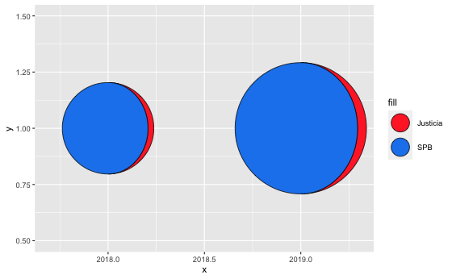

```r
#install.packages('gggibbous')
#library(gggibbous)

tidymoons <- data.frame(
  x = c(2018,2018,2019,2019),
  y = c(1,1,1,1),
  ratio = c(costo_justicia_18/costo_total_18, costo_spb_18/costo_total_18, costo_justicia_19/costo_total_19, costo_spb_19/costo_total_19),
  right = c(TRUE, FALSE, TRUE, FALSE),
  fill = c('Justicia','SPB','Justicia','SPB'),
  size = c(costo_total_18,costo_total_18,costo_total_19,costo_total_19))


ggplot(tidymoons) +
  geom_moon(aes(x, y, ratio = ratio, right = right, fill = fill, size = size),
            key_glyph = draw_key_full_moon
  ) +
  lims(x = c(2017.7, 2019.3), y = c(0.5, 1.5)) +
  scale_size("size", range = c(50,50*costo_total_19/costo_total_18), breaks = 2^(1:3)) +
  scale_fill_manual(values = c("firebrick1", "dodgerblue2")) +
  theme(legend.box = "horizontal")
```

#### Cambio de gasto de 2018 a 2019

```r
cat(paste0('Desde el 2018 al 2019 hubo un incremento porcentual del gasto relacionado a ley 23737 de: %',
             round((costo_total_19-costo_total_18)/costo_total_18*100,2) ,'\nDesagregado:\nIncremento porcentual del SPB: %', round((costo_spb_19-costo_spb_18)/costo_spb_18*100 ,2),'\nIncremento porcentual de Justicia: %', round((costo_justicia_19-costo_justicia_18)/costo_justicia_18*100 ,2)))
```

```
Desde el 2018 al 2019 hubo un incremento porcentual del gasto relacionado a ley 23737 de: %43.54
Desagregado:
Incremento porcentual del SPB: %42.9
Incremento porcentual de Justicia: %52.84
```